# Texas_Power_Crisis

Benjamin Versteeg

2022-12-15

## Overview

“In February 2021, the state of Texas suffered a major power crisis, which came about as a result of three severe winter storms sweeping across the United States on February 10–11, 13–17, and 15–20.”[^1] For more background, check out these [engineering](https://www.youtube.com/watch?v=08mwXICY4JM&ab_channel=PracticalEngineering) and [political](https://www.youtube.com/watch?v=Zcrsgdl_hP0&ab_channel=Vox) perspectives.

Topics this notebook will cover:  
- estimating the number of homes in Houston that lost power as a result of the first two storms  
- investigating if socioeconomic factors are predictors of communities recovery from a power outage

The analysis will be based on remotely-sensed night lights data, acquired from the [Visible Infrared Imaging Radiometer Suite (VIIRS)](https://en.wikipedia.org/wiki/Visible_Infrared_Imaging_Radiometer_Suite) onboard the Suomi satellite. In particular, we will use the VNP46A1 to detect differences in night lights before and after the storm to identify areas that lost electric power.

To determine the number of homes that lost power, we will link (spatially join) these areas with [OpenStreetMap](https://www.openstreetmap.org/#map=4/38.01/-95.84) data on buildings and roads.

To investigate potential socioeconomic factors that influenced recovery, the analysis will be linked with data from the US Census Bureau.

#### Highlights

- load vector/raster data
- simple raster operations
- simple vector operations
- spatial joins

## Data

#### Night lights

Use NASA’s Worldview to explore the data around the day of the storm. There are several days with too much cloud cover to be useful, but 2021-02-07 and 2021-02-16 provide two clear, contrasting images to visualize the extent of the power outage in Texas.

VIIRS data is distributed through NASA’s [Level-1 and Atmospheric Archive & Distribution System Distributed Active Archive Center (LAADS DAAC)](https://ladsweb.modaps.eosdis.nasa.gov/). Many NASA Earth data products are distributed in 10x10 degree tiles in sinusoidal equal-area projection. Tiles are identified by their horizontal and vertical position in the grid. Houston lies on the border of tiles h08v05 and h08v06. We therefore need to download two tiles per date.

Accessing, downloading, and preparing remote sensing data is a skill in it’s own right! To prevent this notebook from being a large data wrangling challenge, the following files are prepped and stored in the `VNP46A1` folder.

- `VNP46A1.A2021038.h08v05.001.2021039064328.h5.tif`: tile h08v05, collected on 2021-02-07
- `VNP46A1.A2021038.h08v06.001.2021039064329.h5.tif`: tile h08v06, collected on 2021-02-07
- `VNP46A1.A2021047.h08v05.001.2021048091106.h5.tif`: tile h08v05, collected on 2021-02-16
- `VNP46A1.A2021047.h08v06.001.2021048091105.h5.tif`: tile h08v06, collected on 2021-02-16

#### Roads

Typically highways account for a large portion of the night lights observable from space (see Google’s [Earth at Night](https://earth.google.com/web/@27.44405464,-84.7693044,206.63660162a,8916361.52264659d,35y,0h,0t,0r/data=CiQSIhIgMGY3ZTJkYzdlOGExMTFlNjk5MGQ2ZjgxOGQ2OWE2ZTc)). To minimize falsely identifying areas with reduced traffic as areas without power, we will ignore areas near highways.

[OpenStreetMap (OSM)](https://planet.openstreetmap.org/) is a collaborative project which creates publicly available geographic data of the world. Ingesting this data into a database where it can be subsetted and processed is a large undertaking. Fortunately, third party companies redistribute OSM data. We used [Geofabrik’s download sites](https://download.geofabrik.de/) to retrieve a shapefile of all highways in Texas and prepared a Geopackage (`.gpkg` file) containing just the subset of roads that intersect the Houston metropolitan area.

- `gis_osm_roads_free_1.gpkg`

#### Houses

We can also obtain building data from OpenStreetMap. We again downloaded from Geofabrick and prepared a GeoPackage containing only houses in the Houston metropolitan area.

- `gis_osm_buildings_a_free_1.gpkg`

#### Socioeconomic

We cannot readily get socioeconomic information for every home, so instead we obtained data from the [U.S. Census Bureau’s American Community Survey](https://www.census.gov/programs-surveys/acs) for census tracts in 2019. The *folder* `ACS_2019_5YR_TRACT_48.gdb` is an ArcGIS [“file geodatabase”](https://desktop.arcgis.com/en/arcmap/latest/manage-data/administer-file-gdbs/file-geodatabases.htm), a multi-file proprietary format that’s roughly analogous to a GeoPackage file.

We can use `st_layers()` to explore the contents of the geodatabase. Each layer contains a subset of the fields documents in the [ACS metadata](https://www2.census.gov/geo/docs/maps-data/data/tiger/prejoined/ACSMetadata2011.txt).

The geodatabase contains a layer holding the geometry information, separate from the layers holding the ACS attributes. We’ll have to combine the geometry with the attributes to get a feature layer that `sf` can use.

## Find Locations of Blackouts

For improved computational efficiency and easier interoperability with `sf`, it is recommend to use the `stars` package for raster handling.

### Combining the Data

Steps:

- read in night lights tiles
- combine tiles into a single `stars` object for each date (2021-02-07 and 2021-02-16)

```r
# load in necessary packages
library(stars)
library(tidyverse)
library(sf)
library(tmap)
library(raster)
library(terra)
library(ggplot2)
```

```r
# read in the tile data
night_lights07_1 <- read_stars("~/MEDS/MEDS_223/Projects/Texas_Power_Crisis/data/VNP46A1/VNP46A1/VNP46A1.A2021038.h08v05.001.2021039064328.tif")

night_lights07_2 <- read_stars("~/MEDS/MEDS_223/Projects/Texas_Power_Crisis/data/VNP46A1/VNP46A1/VNP46A1.A2021038.h08v06.001.2021039064329.tif")

night_lights16_1 <- read_stars("~/MEDS/MEDS_223/Projects/Texas_Power_Crisis/data/VNP46A1/VNP46A1/VNP46A1.A2021047.h08v05.001.2021048091106.tif")

night_lights16_2 <- read_stars("~/MEDS/MEDS_223/Projects/Texas_Power_Crisis/data/VNP46A1/VNP46A1/VNP46A1.A2021047.h08v06.001.2021048091105.tif")
```

```r
# combine data into single stars objects for each day
night_lights07 <- st_mosaic(night_lights07_1, night_lights07_2)
night_lights16 <- st_mosaic(night_lights16_1, night_lights16_2)
```

### Creating a Blackout Mask

Steps:

- find the change in night lights intensity (presumably) caused by the storm
- reclassify the difference raster, assuming that any location that experienced a drop of more than 200 nW cm<sup>-2</sup>sr<sup>-1</sup> experienced a blackout
- assign `NA` to all locations that experienced a drop of *less* than 200 nW cm<sup>-2</sup>sr<sup>-1</sup>

```r
# light difference between the two dates
light_dif <- night_lights07 - night_lights16

# assigned NA to all locations that experienced a drop of less than 200 nW cm-2sr-1
blackout_mask <- cut(light_dif, c(200, Inf), labels = "NA")
```

### Vectorizing the Mask

Steps:

- use `st_as_sf()` to vectorize the blackout mask
- fix any invalid geometries using `st_make_valid`

```r
# vectorize blackout mask and fix invalid geometries
blackout_vector <- st_as_sf(blackout_mask) %>%
  st_make_valid()
```

### Cropping the Vectorized Map to the Region of Interest

Let’s look at Houston specifically and how much power it lost during the storms.

Steps:

- define the Houston metropolitan area with the following coordinates
  - (-96.5, 29), (-96.5, 30.5), (-94.5, 30.5), (-94.5, 29)
- turn these coordinates into a polygon using `st_polygon`
- convert the polygon into a simple feature collection using `st_sfc()` and assign a CRS
- crop (spatially subset) the blackout mask to the Houston area
- re-project the cropped blackout dataset to EPSG:3083 (NAD83 / Texas Centric Albers Equal Area)

```r
# defining Houston area with coords
houst_coords <- matrix(c(-96.5, 29, -96.5, 30.5, -94.5, 30.5, -94.5, 29, -96.5, 29), ncol = 2, byrow = TRUE)

# creating a polygon of Houston's coordinates and crs
houst_poly <- st_polygon(list(houst_coords)) %>% st_sfc(crs = 4326)

# cropping the blackout mask with Houston polygon
houst_crop <- blackout_vector[houst_poly, ,]

# reproject cropped dataset, add 3083 crs and convert to sf
houst_3083 <- st_transform(houst_crop, crs = 3083) %>% st_as_sf(houst_crop)
```

### Excluding Highways From Blackout Mask

The roads geopackage includes data on roads other than highways. However, we can avoid reading in data we don’t need by taking advantage of `st_read`’s ability to subset using a SQL query.

Steps:

- define SQL query
- load just highway data from geopackage using `st_read`
- reproject data to EPSG:3083
- identify areas within 200m of all highways using `st_buffer`
- find areas that experienced blackouts that are further than 200m from a highway

`query <- "SELECT * FROM gis_osm_roads_free_1 WHERE fclass='motorway'"`  
`highways <- st_read("data/gis_osm_roads_free_1.gpkg", query = query)`

```r
# read in highway data using SQL query and st_read()
query <- "SELECT * FROM gis_osm_roads_free_1 WHERE fclass='motorway'"
highways <- st_read("~/MEDS/MEDS_223/Projects/assignment-3-BenVerst/data/gis_osm_roads_free_1.gpkg/gis_osm_roads_free_1.gpkg", query = query)
```

```
## Reading query `SELECT * FROM gis_osm_roads_free_1 WHERE fclass='motorway''
## from data source `C:\Users\17143\Documents\MEDS\MEDS_223\Projects\assignment-3-BenVerst\data\gis_osm_roads_free_1.gpkg\gis_osm_roads_free_1.gpkg'
##   using driver `GPKG'
## Simple feature collection with 6085 features and 10 fields
## Geometry type: LINESTRING
## Dimension:     XY
## Bounding box:  xmin: -96.50429 ymin: 29.00174 xmax: -94.39619 ymax: 30.50886
## Geodetic CRS:  WGS 84
```

```r
# select the geometry highway data
highway_geom <- highways$geom

# use st_transform to make the highway geometries to 3083 crs
highway_geom <- st_transform(highway_geom, crs = 3083)

# create a buffer zone of 200 meters
highway_buffer <- st_buffer(x = highway_geom, dist = 200)

# combine the geometries and create a mask that excludes highway data
highway_buffer <- st_union(highway_buffer, by_feature = FALSE)
houst_high_mask <- houst_3083[highway_buffer, , op = st_disjoint]
```

## Find Homes Impacted by Blackouts

### Loading Buildings Data

- load buildings dataset using `st_read` and the following SQL query to select only residential buildings
- reproject data to EPSG:3083

`SELECT *` `FROM gis_osm_buildings_a_free_1`  
`WHERE (type IS NULL AND name IS NULL)`  
`OR type in ('residential', 'apartments', 'house', 'static_caravan', 'detached')`

```r
# define query
query_houses <- "SELECT * FROM gis_osm_buildings_a_free_1 WHERE (type IS NULL AND name IS NULL) OR type in ('residential', 'apartments', 'house', 'static_caravan', 'detached')"

# read in highway data with SQL
houses <- st_read("~/MEDS/MEDS_223/Projects/assignment-3-BenVerst/data/gis_osm_buildings_a_free_1.gpkg/gis_osm_buildings_a_free_1.gpkg", query = query_houses)
```

```
## Reading query `SELECT * FROM gis_osm_buildings_a_free_1 WHERE (type IS NULL AND name IS NULL) OR type in ('residential', 'apartments', 'house', 'static_caravan', 'detached')'
## from data source `C:\Users\17143\Documents\MEDS\MEDS_223\Projects\assignment-3-BenVerst\data\gis_osm_buildings_a_free_1.gpkg\gis_osm_buildings_a_free_1.gpkg'
##   using driver `GPKG'
## Simple feature collection with 475941 features and 5 fields
## Geometry type: MULTIPOLYGON
## Dimension:     XY
## Bounding box:  xmin: -96.50055 ymin: 29.00344 xmax: -94.53285 ymax: 30.50393
## Geodetic CRS:  WGS 84
```

```r
houses <- st_transform(houses, "EPSG:3083")
```

### Finding Homes in Blackout Areas

Steps:

- filter to homes within blackout areas
- count number of impacted homes

```r
class(houses)
```

```
## [1] "sf"         "data.frame"
```

```r
# filtering
outage_houses <- houses[houst_high_mask ,drop = FALSE]

nrow(outage_houses)
```

```
## [1] 138652
```

## Investigate Socioeconomic Factors

### Loading in ACS Data

Steps:

- use `st_read()` to load the geodatabase layers
- geometries are stored in the `ACS_2019_5YR_TRACT_48_TEXAS` layer
- income data is stored in the `X19_INCOME` layer
- select the median income field `B19013e1`
- reproject data to EPSG:3083

```r
#reading in geometry data
census_geom <- st_read("~/MEDS/MEDS_223/Projects/assignment-3-BenVerst/data/ACS_2019_5YR_TRACT_48_TEXAS.gdb/ACS_2019_5YR_TRACT_48_TEXAS.gdb", layer = "ACS_2019_5YR_TRACT_48_TEXAS")
census_geom <- st_transform(census_geom, crs = 3083)

#reading in income data
med_income <- st_read("~/MEDS/MEDS_223/Projects/assignment-3-BenVerst/data/ACS_2019_5YR_TRACT_48_TEXAS.gdb/ACS_2019_5YR_TRACT_48_TEXAS.gdb", layer = "X19_INCOME")
#selecting for my coloums
sel_med_income <- med_income |>
  dplyr::select("GEOID", "B19013e1") |>
  rename(GEOID_Data = GEOID, median_income = B19013e1)
```

### Determining Which Census Tracts Experienced Blackouts

Steps:

- join the income data to the census tract geometries
- spatially join census tract data with buildings determined to be impacted by blackouts
- find which census tracts had blackouts

```r
# check the class
class(census_geom)
```

```
## [1] "sf"         "data.frame"
```

```r
class(sel_med_income)
```

```
## [1] "data.frame"
```

```r
# change to a data_frame
sel_med_income_df <- tibble(sel_med_income)

# join census and median income data
census_data <- left_join(census_geom,
                         sel_med_income,
                         by = "GEOID_Data")

# change to the 4326 crs
census_data <- st_transform(census_data, crs = 4326)
outage_houses <- st_transform(outage_houses, crs = 4326)

# check the class
class(census_data)
```

```
## [1] "sf"         "data.frame"
```

```r
class(outage_houses)
```

```
## [1] "sf"         "data.frame"
```

```r
# filter census data using the outage houses. also add a column which tracts were a blackout
census_outage <- sf::st_filter(census_data, outage_houses) |>
  mutate(blackout = 'yes')
```

### Comparing Incomes of Impacted Tracts to Unimpacted Tracts

Steps:

- create a map of median income by census tract, designating which tracts had blackout
- plot the distribution of income in impacted and unimpacted tracts

```r
# crop census data with Houston border
houst_census_data <- census_data[houst_poly, ,]

# transform census data to 3083 crs
houst_census_data <- st_transform(houst_census_data, crs = 3083)

# select columns for houston census
houst_census_data <- houst_census_data |>
  dplyr::select("NAMELSAD", "Shape", "median_income", "GEOID_Data")

# select columns for outage data by census track
census_outage <- census_outage |>
  dplyr::select("blackout", "GEOID_Data")
census_outage_map <- census_outage |>
  dplyr::select("blackout")

# convert census outage data to dataframe
census_outage_df <- as.data.frame(census_outage)

# join census outage data and census data for Houston
census_map_data <- left_join(houst_census_data,
                             census_outage_df,
                             by = "GEOID_Data")

census_map_data <- census_map_data |>
  dplyr::select('median_income', 'blackout')
```

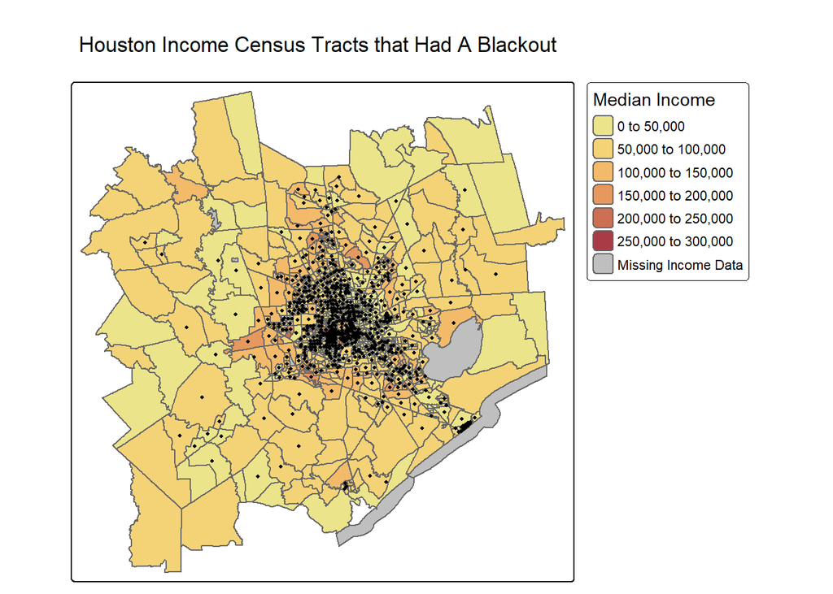

```r
# Map median income by census track and identifying outages
tm_shape(census_map_data) +

  # Add polygons representing median income with a heat color palette
  tm_polygons("median_income",
              palette = 'heat',
              textNA = "Missing Income Data", # Label for areas with missing income data
              title = "Median Income") + # Title

  # Add a new layer using census_outage_map
  tm_shape(census_outage_map) +

    # Add dots to represent outages
    tm_dots(shape = 16,        # Shape code for filled circles
            size = .2,         # Size of the dots
            col = "black",     # Set the color of dots to black
            title = 'blackout') +  # Legend title for the dots

  # Set the layout options for the entire map
  tm_layout(main.title = "Houston Income Census Tracts that Had A Blackout", # Main title of the map
            legend.outside = TRUE,  # Display the legend outside the map
            main.title.size = 1)    # Set the size of the main title
```

```r
# convert census map data to dataframe
census_plot_data <- data_frame(census_map_data)

# add homes that didn't have a blackout
census_plot_data <- census_plot_data |>
  mutate(blackout = replace(blackout, is.na(blackout), "no"))

# dataframe for homes with a blackout
census_plot_data_blackout <- census_plot_data |>
  dplyr::select("median_income", "blackout") |>
  filter(blackout == "yes")


# dataframe for homes with no blackout
census_plot_data_no_blackout <- census_plot_data |>
  dplyr::select("median_income", "blackout") |>
  filter(blackout == "no")
```

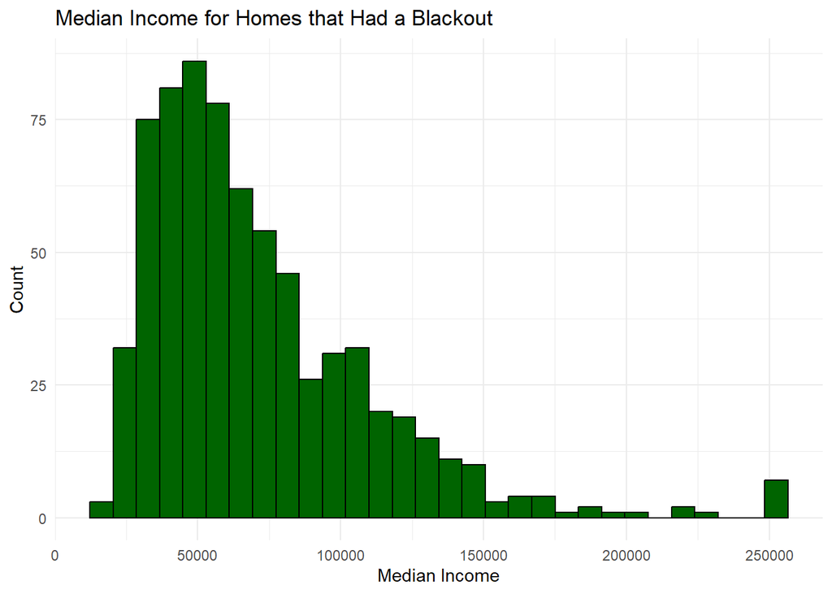

```r
# Plotting census data that experienced a blackout

# Create a histogram using ggplot with census_plot_data_blackout
ggplot(census_plot_data_blackout, aes(x = median_income)) +
  # Add histogram bars with black outline and dark green fill
  geom_histogram(color = "black", fill = "darkgreen") +
  labs(
    title = "Median Income for Homes that Had a Blackout", # Title
    x = "Median Income",                                   # X-axis label
    y = "Count"                                            # Y-axis label
  ) +
  # Set the theme to minimal
  theme_minimal()
```

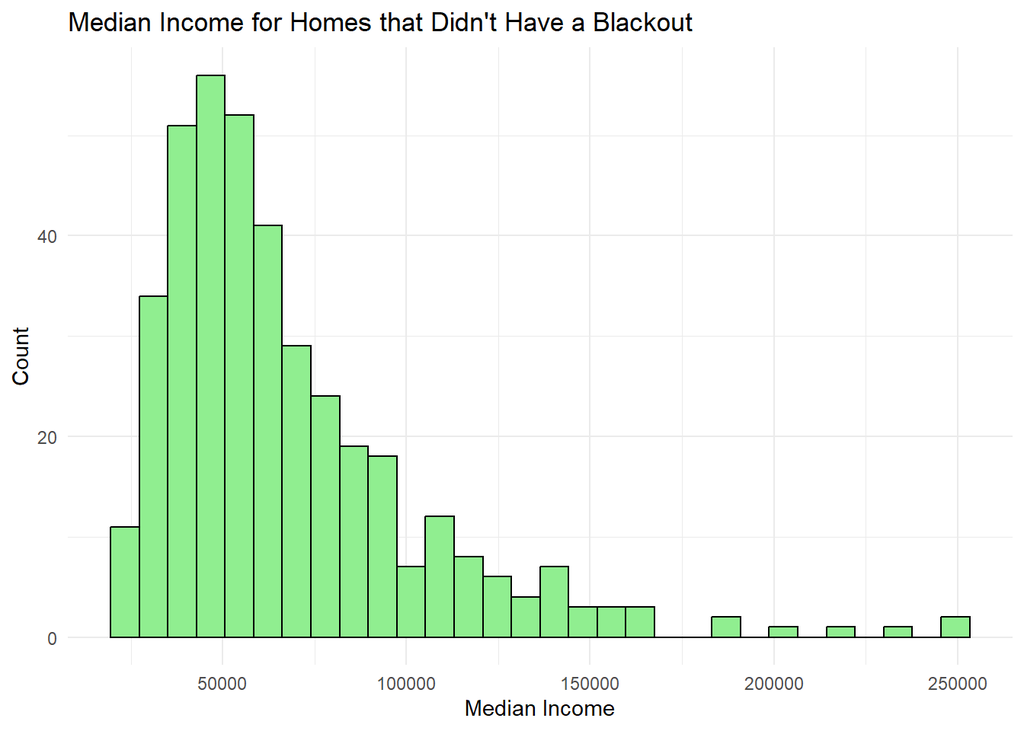

```r
# Plotting census data that didn't experience a blackout

# Create a histogram using ggplot with census_plot_data_no_blackout
ggplot(census_plot_data_no_blackout, aes(x = median_income)) +
  # Add histogram bars with black outline and light green fill
  geom_histogram(color = "black", fill = "lightgreen") +
  labs(
    title = "Median Income for Homes that Didn't Have a Blackout", # Plot title
    x = "Median Income",                                           # X-axis label
    y = "Count"                                                    # Y-axis label
  ) +
  # Set the theme to minimal
  theme_minimal()
```

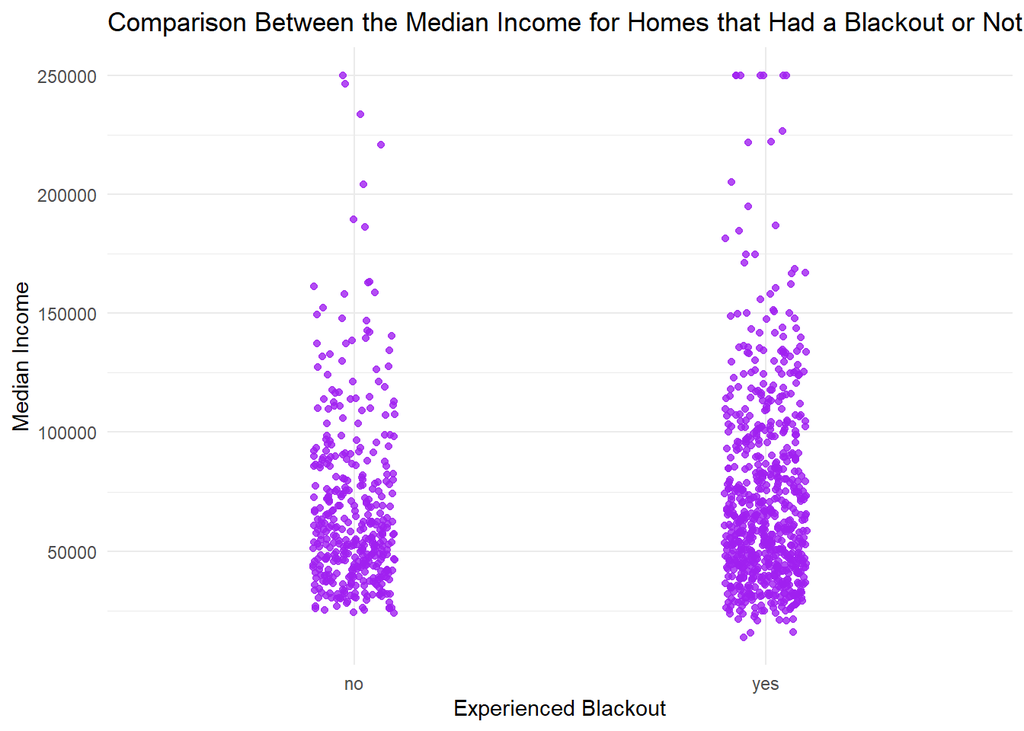

```r
# Create a scatter plot comparing median income for homes that had a blackout or not
ggplot(census_plot_data, aes(x = blackout, y = median_income)) +
  # Add jittered points for better visualization
  geom_jitter(width = 0.1,          # Width of jitter
              height = 0,           # Height of jitter
              color = "purple",     # Point color
              alpha = 0.8) +        # Transparency of points
  labs(
    title = "Comparison Between the Median Income for Homes that Had a Blackout or Not",  # Plot title
    x = "Experienced Blackout",  # X-axis label
    y = "Median Income"          # Y-axis label
  ) +
  # Set the theme to minimal
  theme_minimal()
```

```r
# Display summary statistics for homes that had a blackout
summary(census_plot_data_blackout)
```

```
##  median_income      blackout
##  Min.   : 13886   Length:710
##  1st Qu.: 43735   Class :character
##  Median : 60634   Mode  :character
##  Mean   : 71435
##  3rd Qu.: 89864
##  Max.   :250001
##  NA's   :3
```

```r
# Display summary statistics for homes that didn't have a blackout
summary(census_plot_data_no_blackout)
```

```
##  median_income      blackout
##  Min.   : 24024   Length:402
##  1st Qu.: 43383   Class :character
##  Median : 57049   Mode  :character
##  Mean   : 67494
##  3rd Qu.: 80796
##  Max.   :250001
##  NA's   :7
```

[^1]: Wikipedia. 2021. “2021 Texas power crisis.” Last modified October 2, 2021. https://en.wikipedia.org/wiki/2021_Texas_power_crisis.